# assignment1

Claire Wang

9/9/2020

```r
library(ggplot2)
library(tidyverse)
library(tidycensus)
library(viridis)
library(prettydoc)
library(hexbin)
library(ggthemes)
library(GGally)
library(treemap)
```

##Variables Categorical1:racial compositions in the neighborhood as majority race (majority_race_eth) – thanks to the contribution of the class file on github. Categorical2:reasons for vacancy (vac_by) Categorical3:marital status of the female householder - if they are separate, divorced or widowed. (m_status) Categorical4: high female educational attainments- college, masters and doctors (edchigh) Continuous1:total number of household (tot_hh) Continuous2:total vacancies (tot_vac) Continuous3:median age (med_age) Continuous4:median income (med_inc) Continuous5:total occupancy (tot_ocu) Continuous6: Number of grandparents responsible for childcare under(grandpc18)

```r
vars <- c(tot_hh = "H001001",
         tot_vac = "H003003",
         tot_vac_rent = "H005002",
         tot_vac_sal="H005004",
         tot_ocu = "H003002",
         tot_pop = "P003001",
         nh_whiteown = "H006002",
         nh_blackown = "H006003",
         nh_asianown = "H006005",
         nh_morerace = "H006008",
         med_age="P013001"
        )

varacs <-c(f_divorced="B12001_019",
         f_widow="B12002D_012",
        f_separate="B12002D_011",
        f_college="B15002_032",
          f_master="B15002_033",
          f_phd="B15002_035",
        grandpc18="B10002_002",
        med_inc=    "B06011_001"
)

acs<- get_acs(geography = "tract", variables = varacs,
                           state = "PA", county = "Philadelphia County",year=2018,
                           output = "wide",survey = "acs5")

census <- get_decennial(geography = "tract", variables = vars,
                           state = "PA", county = "Philadelphia",
                           output = "wide")

philly_tracts <- inner_join(acs, census, by = "GEOID") %>%
  mutate(pct_vac = tot_vac/tot_hh,
         pct_ocu = tot_ocu/tot_hh,
         pct_divorced= f_divorcedE/tot_pop,
         pct_widow= f_widowE/tot_pop,
         pct_separate= f_separateE/tot_pop,
         pct_college = f_collegeE/tot_pop,
         pct_master = f_masterE/tot_pop,
         pct_phd = f_phdE/tot_pop,

         vac_by= case_when(
           tot_vac_sal/tot_vac >0.5 ~"selling",
           tot_vac_rent/tot_vac >0.5 ~"renting",
           (tot_vac_sal+tot_vac_rent)/tot_vac < 0.5 ~"other"
         ),

         m_status= case_when(
           pct_divorced+pct_separate+pct_widow>0.05 ~"divorced+widow+separate",
           pct_divorced+pct_separate+pct_widow<0.05 ~"others"
         ),

         edchigh= case_when(
           pct_master+pct_phd >0.1 ~"v_high",
           (pct_master+pct_phd<0.1) & (pct_college > 0.1) ~ "high_ed",
           pct_college < 0.1 ~ "not_so_high"
         ),

         majority_race_eth = case_when(
           nh_whiteown / tot_hh > 0.5 ~ "nh_white",
           nh_blackown / tot_hh > 0.5 ~ "nh_black",
           nh_asianown / tot_hh > 0.5 ~ "nh_asian",
           nh_morerace/ tot_hh > 0.5 ~ "more than one",
           (nh_whiteown + nh_blackown + nh_asianown + nh_morerace) /
             tot_hh < 0.5 ~ "other",
           TRUE ~ "None")) %>%

  filter(tot_pop > 0, tot_hh > 0, pct_vac<0.8) %>%
  select(GEOID, pct_vac, majority_race_eth, tot_vac,tot_ocu,tot_pop,vac_by,med_age,tot_hh,f_divorcedE,f_widowE,f_separateE,f_collegeE,f_phdE,f_masterE,pct_divorced,pct_widow,pct_separate,pct_college,pct_phd,pct_master,grandpc18E, med_incE,edchigh,m_status
        )
```

```r
overall <- ggplot(philly_tracts,
       aes(x = pct_vac,
           y = med_age,
           size = grandpc18E,
           color = vac_by,
           alpha=0.5
           )) +
  geom_point() +
  scale_size_continuous(name = "# of grandparents responsible children") +
  scale_x_continuous(name = "Percent of vacancy",
                     breaks = seq(0, 1, by = 0.1),
                     labels = paste(seq(0, 100, by = 10), "%", sep = "")) +
  scale_y_continuous(name = "Median age within tract",
                     breaks = seq(0, 60, by = 5)) +
  scale_color_discrete(name = "reason for vacancy",
                       labels = c("selling",
                                  "renting",
                                  "other"
                                  ),
                      ) +
  theme_minimal() +
  scale_color_viridis(discrete = TRUE, option = "D")
  theme(legend.key.size = unit(0.1, "cm"))
```

```
## List of 1
##  $ legend.key.size: 'unit' num 0.1cm
##   ..- attr(*, "valid.unit")= int 1
##   ..- attr(*, "unit")= chr "cm"
##  - attr(*, "class")= chr [1:2] "theme" "gg"
##  - attr(*, "complete")= logi FALSE
##  - attr(*, "validate")= logi TRUE
```

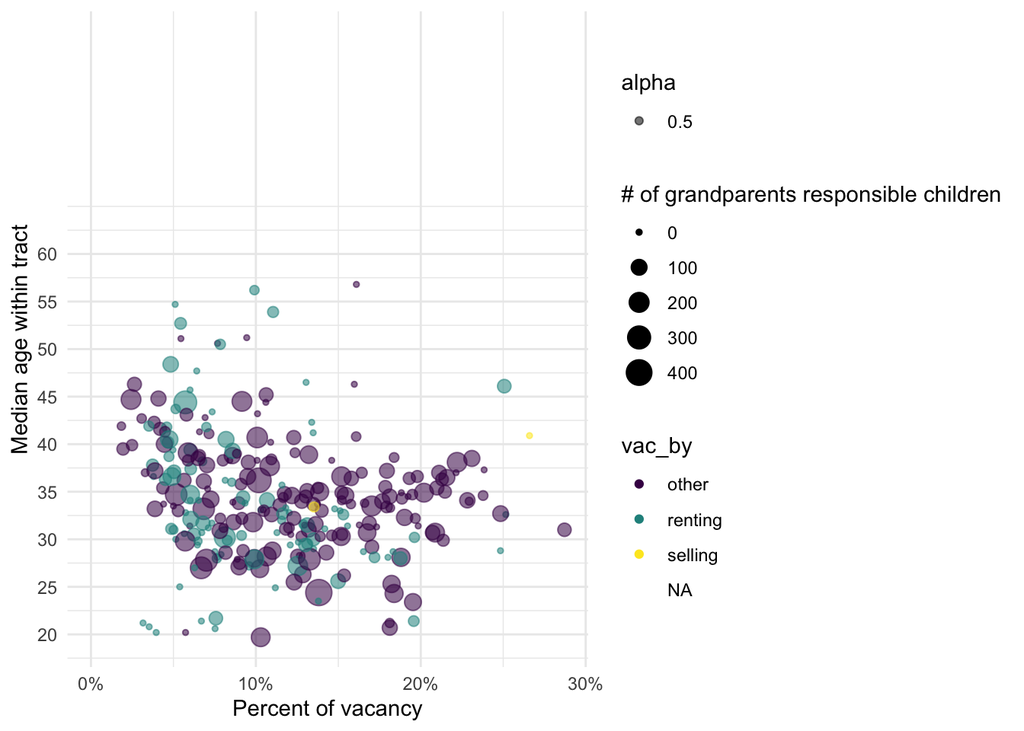

```r
overall
```

##This is a pie chart for different reasons of vacancies.

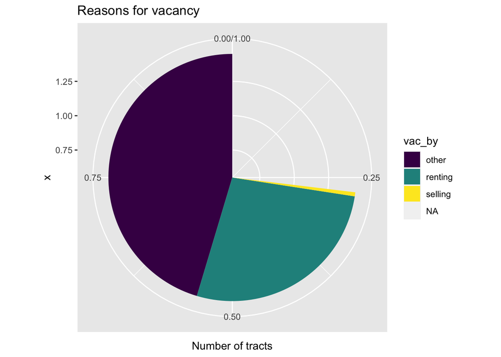

```r
pie_chart <- ggplot(philly_tracts, aes(x = 1, fill = vac_by)) +
  geom_bar(position = "fill") +
  coord_polar(theta = "y") +
  scale_y_continuous(name = "Number of tracts") +
  scale_fill_discrete(name = "Reason for vacancy",
                       labels = c("selling",
                                  "renting",
                                  "other")) +
  ggtitle("Reasons for vacancy")+
  scale_fill_viridis(discrete = TRUE, option = "D")
  theme_minimal()

pie_chart
```

##This is a violin plot of perentage vacancy of different races.

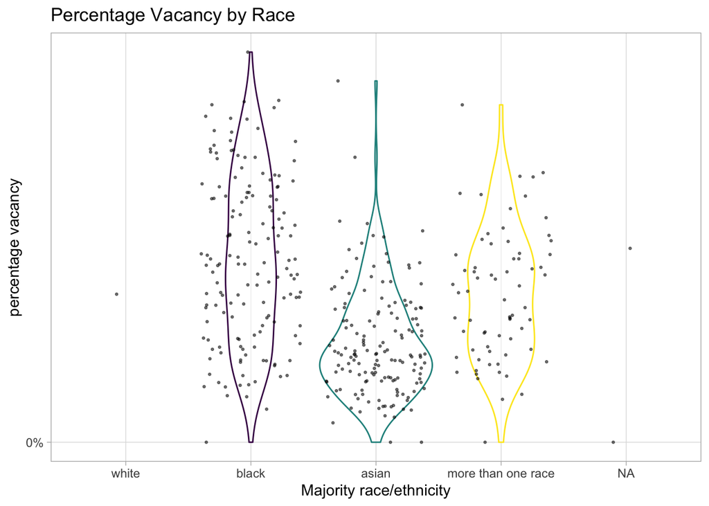

```r
violin<- ggplot(philly_tracts,
       aes(x = majority_race_eth,
           y = pct_vac
           )

           ) +
  geom_violin(aes(color=majority_race_eth),alpha=0.5) +
  geom_point(position = "jitter",
             alpha = 0.5,
             size = 0.5,

             ) +
  scale_x_discrete(name = "Majority race/ethnicity",
                       labels = c("white",
                                  "black",
                                  "asian",
                                  "more than one race"), ) +
  scale_y_continuous(name = "percentage vacancy",
                     breaks = seq(0, 100, by = 10), labels = paste(seq(0, 100, by = 10), "%", sep = "")) +
  ggtitle("Percentage Vacancy by Race")+
  theme_light() +
  scale_color_viridis(discrete = TRUE, option = "D")+
  theme(legend.position = "below")

violin
```

##This is graph of percentage vacancy across different female educational attainment.

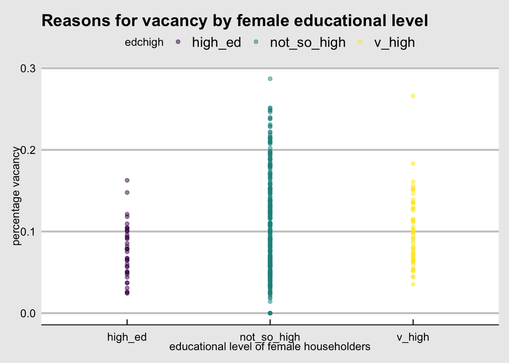

```r
vacVShh<- ggplot(philly_tracts,
       aes(x = edchigh,
           y = pct_vac,
           )) +
  geom_point(aes(color=edchigh),alpha=0.5) +
  scale_y_continuous(name = "percentage vacancy") +
  scale_x_discrete(name = "educational level of female householders"
                    ) +
  ggtitle("Reasons for vacancy by female educational level")+
  scale_color_viridis(discrete = TRUE, option = "D")+
  theme_economist_white()

vacVShh
```

## This is a graph to show the correlation of median income (log of 10) and percentage vacancy. We can tell the lower the income, the more vacant units are in the neighborhood.

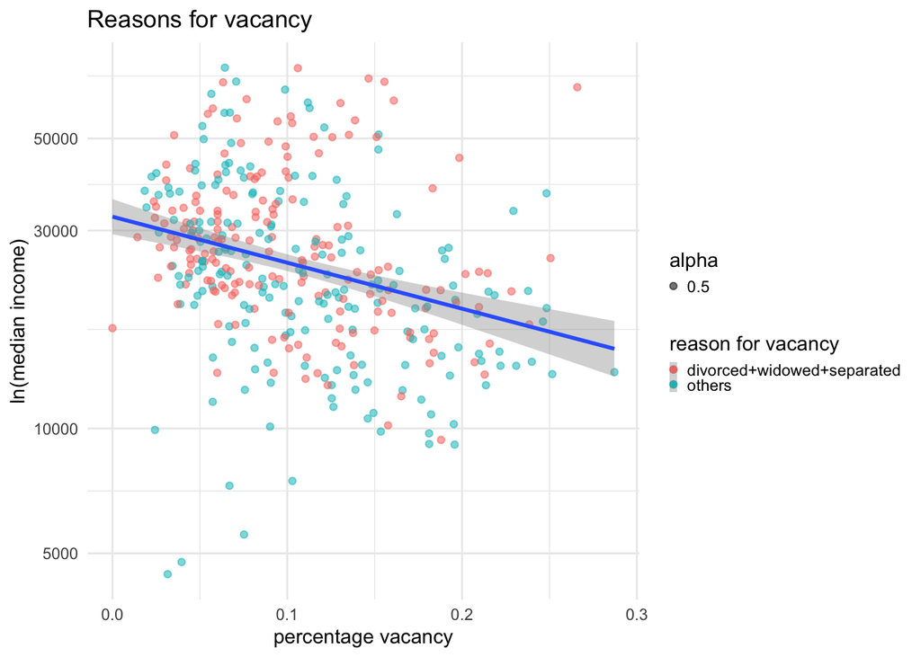

```r
ggplot(philly_tracts, aes(pct_vac, med_incE))+
  geom_point(aes(color = m_status,alpha=0.5)) +
  geom_smooth(aes(color = pct_vac, fill = pct_vac), method = "lm") +
  scale_color_viridis(discrete = TRUE,option="D")+
  scale_fill_viridis(discrete = TRUE,option = "D") +
  scale_y_log10(name = "ln(median income)") +
  scale_x_continuous(name = "percentage vacancy") +
    scale_color_discrete(name = "reason for vacancy",
                       labels = c("divorced+widowed+separated",
                                  "others"
                                  ),
                      ) +
  ggtitle("Reasons for vacancy")+
  theme_minimal() +
  theme(legend.key.size = unit(0.1, "cm"))
```

##This is a heatmap of percentage vacancy between different majority race and female educational attainment.

```r
heat<- ggplot(philly_tracts, aes(edchigh, majority_race_eth, fill= pct_vac)) +
  geom_tile() +
  scale_x_discrete(name="female educational level")+
  scale_y_discrete(name="racial majority")
  ggtitle("Heatmap of percentage vacancy by racial composition and female educational attainment ")+
  scale_fill_viridis(discrete=TRUE,alpha=0.8) +
  theme_minimal()
```

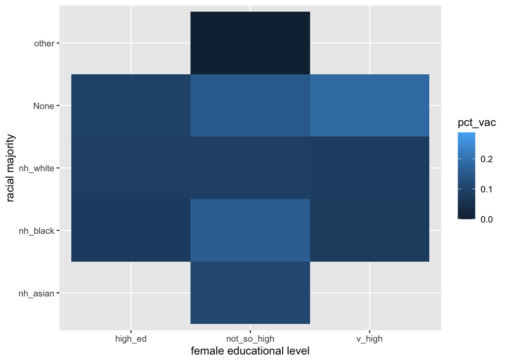

```r
heat
```

##This is a pearson correlation plot between different variable pairs.

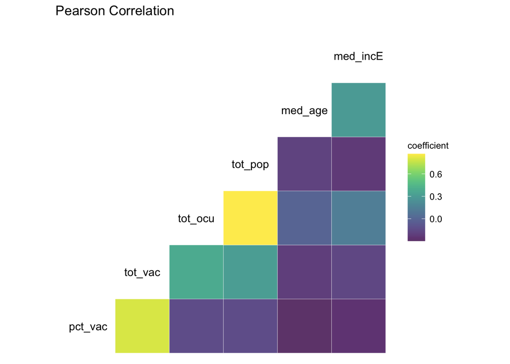

```r
newdf<- philly_tracts [,c("GEOID","pct_vac","majority_race_eth","tot_vac","tot_ocu","tot_pop","vac_by","med_age","med_incE","edchigh","m_status")]

ggcorr(newdf, method = c("pairwise", "pearson")) +
  ggtitle("Pearson Correlation")+
  scale_fill_viridis(discrete=FALSE,alpha=0.8)
```

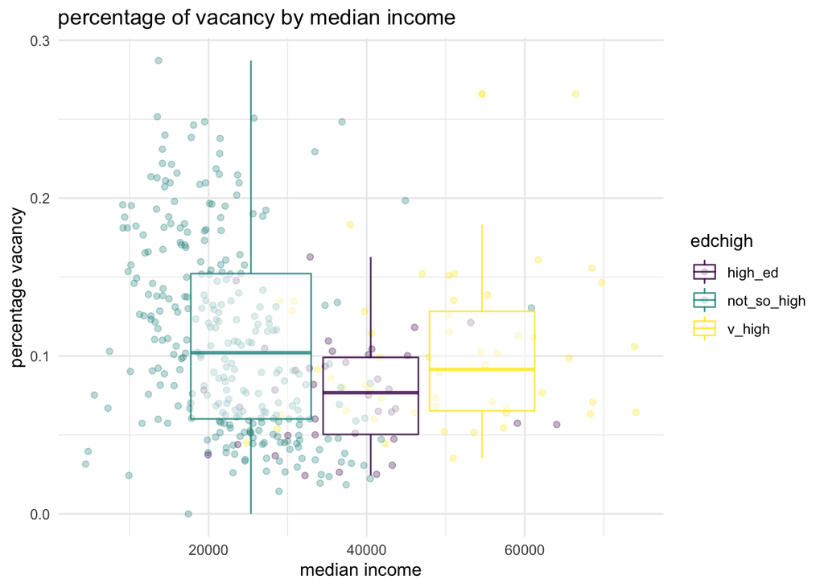

```r
  ggplot(philly_tracts, aes(x=med_incE, y=pct_vac, color = edchigh)) +
    geom_point(alpha=0.3) +
    geom_boxplot(
  data = philly_tracts,
  stat = "boxplot", alpha=0.5)+
    scale_color_viridis(discrete=TRUE, guide=FALSE) +
  ggtitle("percentage of vacancy by median income")+
  scale_x_continuous(name="median income", )+
  scale_y_continuous(name="percentage vacancy")+
  scale_color_discrete(name="female educational level")+
  scale_color_viridis(discrete=TRUE,alpha=0.8,option="D") +
    theme_minimal() +
    theme(legend.position = "right")
```

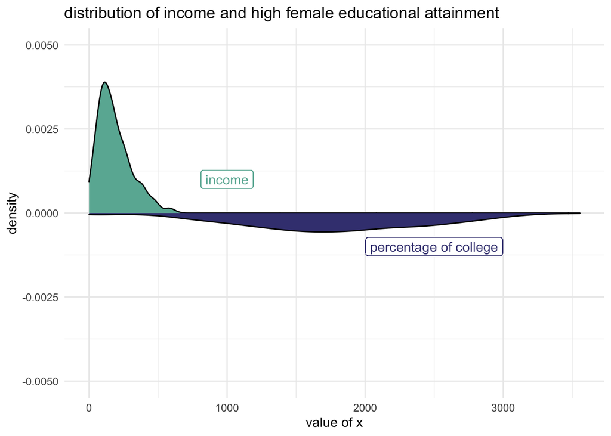

```r
p <- ggplot(philly_tracts, aes(x=med_incE/10000) ) +
  # Top
  geom_density( aes(x = tot_vac, y = ..density..), fill="#69b3a2") +
  geom_label( aes(x=1000, y=0.001, label="income"), color="#69b3a2") +

  # Bottom
  geom_density( aes(x = tot_hh, y = -..density..), fill= "#404080") +
  geom_label( aes(x=2500, y=-0.001, label="percentage of college"), color="#404080") +
coord_cartesian( ylim = c(-0.005, 0.005))+
  theme_minimal() +
  xlab("value of x")+
  ggtitle("distribution of income and high female educational attainment")

p
```

## This is a graph to show the make up of different races for the total vacancy.

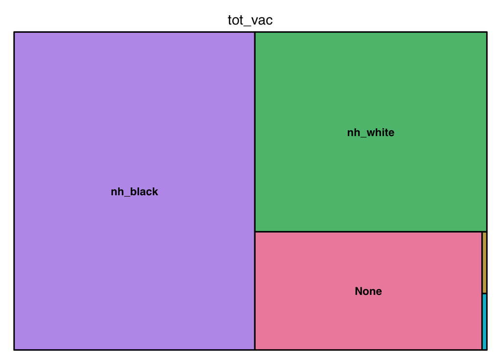

```r
tree<-treemap(philly_tracts,
            index="majority_race_eth",
            vSize="tot_vac",
            aes(color="majority_race_eth"))+
scale_color_viridis(discrete=TRUE, guide=FALSE)
```

```r
tree
```

##This is a bar chart of total vacancy in the tract by different reasons (color stacking) and by the majority race (x-axis).

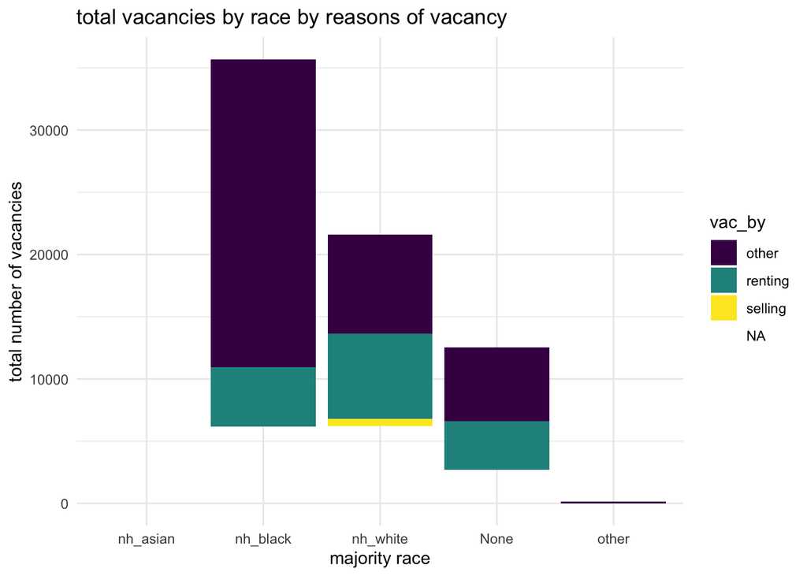

```r
ggplot(philly_tracts, aes(fill=vac_by, y=tot_vac, x=majority_race_eth)) +
    geom_bar(position="stack", stat="identity")+
  scale_x_discrete(name="majority race")+
  scale_y_continuous(name="total number of vacancies")+
  scale_color_discrete(name="reasons for vacancies")+
  scale_fill_viridis(discrete=TRUE)+
  ggtitle("total vacancies by race by reasons of vacancy")+
  theme_minimal()
```

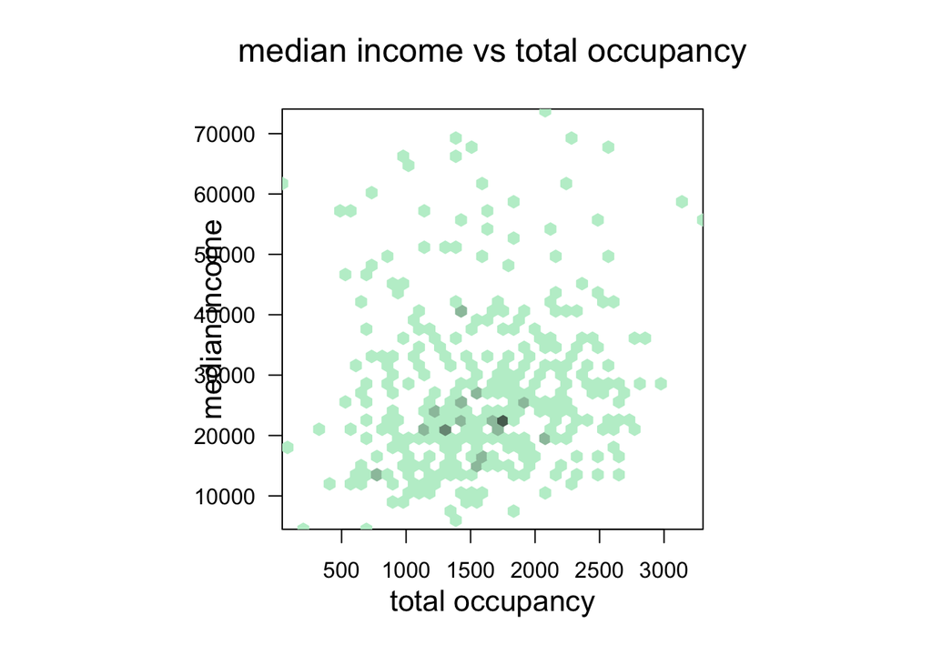

```r
x<- as.numeric(philly_tracts$tot_ocu)
y<-  as.numeric(philly_tracts$med_incE)

bin<-hexbin(x, y, xbins=40)
pal <- colorRampPalette(c("#BEEED0", "#566B5E"))
plot(bin, main="median income vs total occupancy" , legend=F,colramp=pal, xlab="total occupancy", ylab="median income") +
theme_minimal()+
  scale_fill_viridis(discrete=TRUE)
```